# SDS_315_HW_2

# Question 3

## Part A

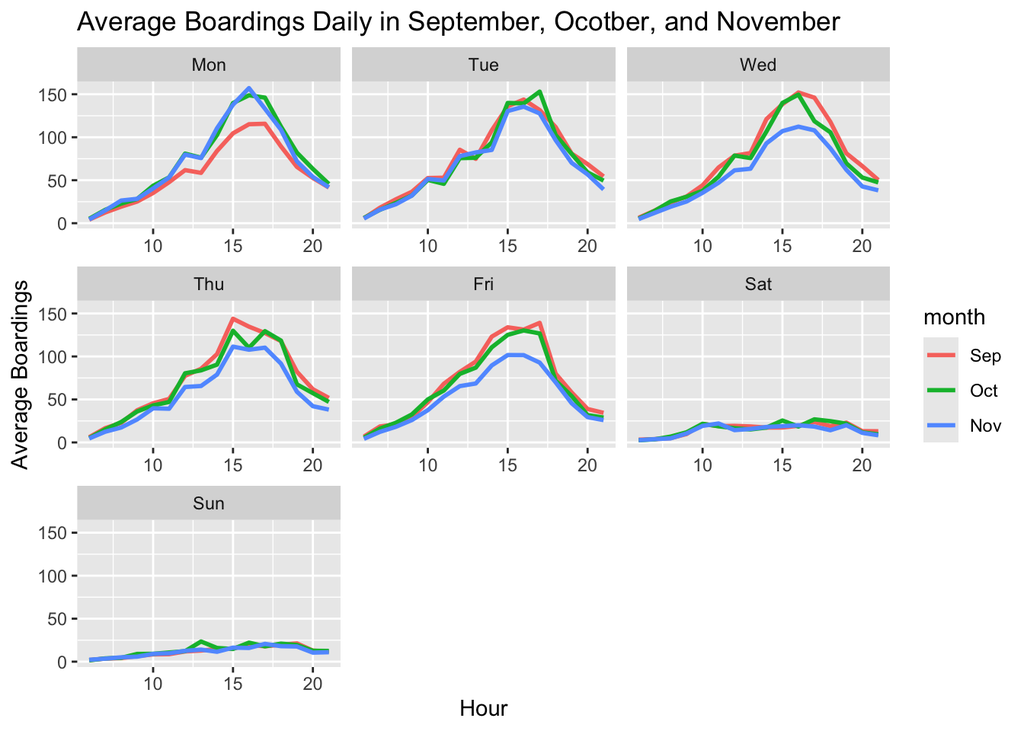

The analysis shows the different days of the week during September October and November and the relationship between number of boarding and the different hours of the day. Most notably was the the peak times for boarding were around 3 PM not specific to what day it was. In addition it displays that September has lower Monday ridership probably because of more semester activity or weekend holidays like labor day. In November the existent of holidays like thanksgiving break likely causes the declines in rates.

## Part B

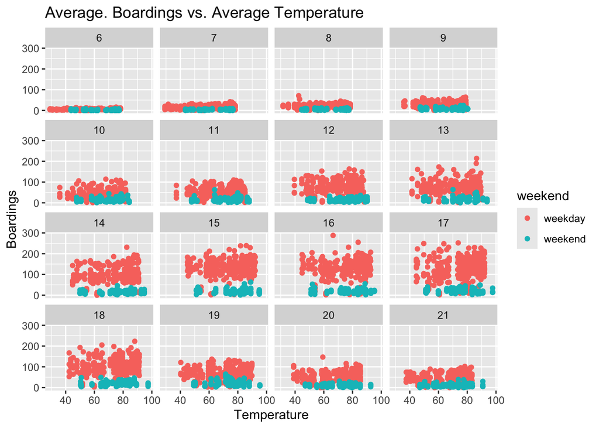